# Relatório 01 - Introdução ao R

Ana Flavia Machado Muniz Andrade

25/04/2022

# 1 Objetivo

Descrever as ideias básicas sobre o ambiente R:

- Como instalar o R e RStudio;
- Diferenças entre o R e a IDE RStudio;
- Como o R trabalha;
- Comandos elementares;
- Objetos;
- Manipulação com objetos;
- Importação de dados;
- Pacotes:
  - Instalação;
  - Como usar.

# 2 Apresentação do relatório

Diante do objetivo do relatório apresentaremos nas próximas subseções, os pontos a serem discutidos.

## 2.1 Como instalar o R e o RStudio

- [Instalação do R](https://cran.r-project.org/bin/windows/base/)
- [Instalação do RStudio](https://rstudio.com/products/rstudio/download/#download)

## 2.3 Como o R trabalha

Ele possui três princípios:

- **Princípio do objeto**: tudo que existe em R é um objeto.
- **Princípio da função**: tudo o que acontece no R é uma chamada de função.
- **Princípio da interface**: interfaces para outros programas são parte do R.

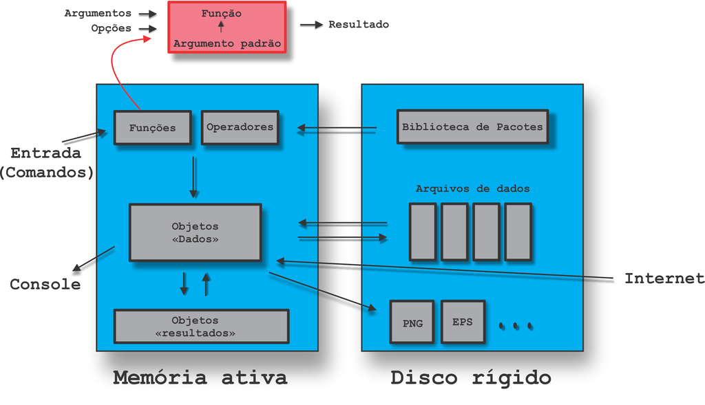

## 2.4 Comandos Elementares

Divididos em: **expressões** e **atribuições**.

- **Expressões**: o R avalia a expressão e imprime o resultado. Caso apareça mensagens indicando “erro”, significa que algum elemento inserido na função não foi reconhecido pelo R.

- **Atribuições**: um nome é relacionado a um objeto, podendo ser recuperado.

## 2.5 Objetos

Reconhecemos um objeto como uma entidade no ambiente R cujas características internas contêm as informações necessárias para explicar sua estrutura e conteúdo. Características essas que são nomeadas atributos.

- **Associando um nome a um objeto**

  > x <- 9

  > 9 -> x
  - Atribuição de comando;
  - Utilizar: <-, ou seja, **<** + **-**;
  - Utilizar o símbolo **=** apenas para definir argumentos de uma função;
- **Nomes sintáticos e Não sintáticos**
  - Letras, dígitos, **.** e _;

## 2.7 Importação de dados

O primeiro passo para a importação é fazer uma preparação, por isso seguimos alguns padrões:

- Evitar símbolos fora do padrão afanumérico;
- Evitar misturas de letras maiúsculas e minúsculas, sempre lembrando dos padrões de nomenclatura do R;
- Deixar a formatação da apresentação de dados em arquivos específicos, por isso devemos evitar comentários ou informações que não se relacionem com o banco de dados;
- Evitar palavras longas ou compostas;

**Importando Dados**

- Função responsável: scan();

> x <- scan()
- Após isso seguiremos o seguinte passo-a-passo:
  - Depois e executarmos o comando acima e apertar ENTER aparecerá no console 1: em que devemos digitar o primeiro valor de x;
  - Para 2: digitar o segundo valor de x;
  - Seguindo assim até todos os valores de x serem colocados, ao final, apertamos duas vezes a tecla ENTER para sair do comando;

Normalmente utilizamos programas para criar o banco de dados e depois o R fará a leitura, porém o formato desse tipo de arquivo não é compatível com o R. Uma outra maneira é realizar a importação de dados pelo próprio R , extensão *RData*.

Com o arquivo já pronto, a leitura dele pode ser feita em poucos passos:

Usando RStudio para importar dados

[figure not shown]

1. Escolher o arquivo

[figure not shown]

2. Configurar a leitura do banco de dados

[figure not shown]

3. Importar dados, conjunto de dados e ligação entre nome e objeto no ambiente global